# D08 · SVD-фильтрация многоканального аудио

**К слайду 8: «Многоканальные сигналы: выделить полезную структуру».** Синтезируем две короткие мелодии, смешаем их в восемь виртуальных каналов и добавим независимый шум. Затем буквально выполним $X=U\Sigma V^\mathsf{T}$ и послушаем, что остаётся при разных рангах.

После выполнения можно объяснить, почему усечение SVD иногда ослабляет шум, почему ранг 1 удаляет тихую полезную мелодию и почему выбор ранга требует предположений о данных.

- **Данные:** полностью локальный синтез; это не запись речи, не запись микрофонного массива и не медицинские данные. Внешние файлы, интернет и GPU не нужны.
- **Среда:** Python 3.10+, `numpy`, `scipy`, `pandas`, `matplotlib`, `IPython`. Установка — через общий `requirements.txt` в этой папке; ядро Jupyter должно использовать ту же среду.
- **Запуск:** `Restart Kernel → Run All`. Основные настройки ниже. Графики, WAV и таблица будут в `outputs/d08/` относительно рабочего каталога ядра.
- **Время:** небольшая матрица $8\times32\,000$; основное вычисление выполняется на CPU. Фактическое время SVD напечатается.

```python
from pathlib import Path
import os
import platform
import sys
import time

import numpy as np
import scipy
from scipy import signal
from scipy.io import wavfile
import pandas as pd
import matplotlib
import matplotlib.pyplot as plt
from IPython.display import Audio, Markdown, display

SEED = 42
FS = 8_000
DURATION_SECONDS = 4.0
NOISE_SNR_DB = 3.0          # Отношение энергий всей чистой матрицы и добавленного шума.
KEEP_RANK = 2              # Предположение: два независимых источника; не выбор по clean SNR.
LISTEN_CHANNEL = 0         # Во всех сравнениях слушаем один и тот же канал.
WRITE_WAV = True
OUTPUT_DIR = Path('outputs/d08')
OUTPUT_DIR.mkdir(parents=True, exist_ok=True)

rng = np.random.default_rng(SEED)
plt.rcParams.update({'figure.dpi': 110, 'font.size': 11, 'axes.spines.top': False,
                     'axes.spines.right': False, 'axes.grid': True, 'grid.alpha': 0.2})
print(f'Python {sys.version.split()[0]} | {platform.platform()}')
print(f'CPU: {platform.processor() or platform.machine()} | logical cores: {os.cpu_count()}')
print(f'NumPy {np.__version__} | SciPy {scipy.__version__} | pandas {pd.__version__} | '
      f'Matplotlib {matplotlib.__version__}')
print(f'Seed: {SEED}; device: CPU; output: {OUTPUT_DIR.resolve()}')
```

```
Python 3.12.14 | macOS-26.6.2-arm64-arm-64bit
CPU: arm | logical cores: 10
NumPy 2.5.3 | SciPy 1.18.1 | pandas 3.0.6 | Matplotlib 3.11.2
Seed: 42; device: CPU; output: /Users/alexey/Documents/projects/life/3. Projects/courses/c01_ModAI/02_linalg/notebooks/applications/outputs/d08
```

## 1. Из двух мелодий получаем восемь каналов

Каждая строка $S\in\mathbb{R}^{2\times T}$ — отдельная синтетическая мелодия с плавной атакой и затуханием, основной частотой и второй гармоникой. Вторая мелодия тише первой и играет в более высоком регистре.

Матрица $A\in\mathbb{R}^{8\times2}$ задаёт известные коэффициенты смешивания:

$$X_{\text{clean}}=AS,\qquad X=X_{\text{clean}}+E.$$

В этой **специально сконструированной модели** ранг чистой матрицы не больше 2. Шум независим между каналами. В реальном помещении задержки, реверберация и движущиеся источники нарушают такую простую модель; число микрофонов само по себе не гарантирует низкий ранг. Знаки коэффициентов здесь обозначают полярность виртуального канала.

```
S: (2, 32000); A: (8, 2); X: (8, 32000); clean rank = 2
Matrix memory: 1.95 MiB; duration: 4.00 s
```

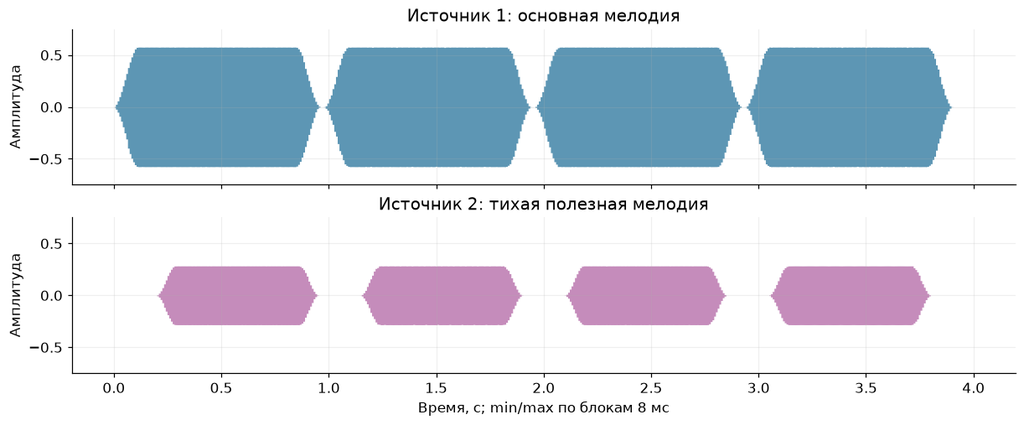

```python
N = round(FS * DURATION_SECONDS)
t = np.arange(N) / FS
assert FS >= 4_000 and DURATION_SECONDS >= 3.9


def make_melody(frequencies, onsets, durations, amplitude):
    """Локальная учебная мелодия; исходники звука и случайность не используются."""
    waveform = np.zeros(N, dtype=np.float64)
    for frequency, onset, duration in zip(frequencies, onsets, durations):
        start = round(onset * FS)
        length = min(round(duration * FS), N - start)
        if length <= 0:
            continue
        local_time = np.arange(length) / FS
        envelope = signal.windows.tukey(length, alpha=0.24)
        tone = (0.82 * np.sin(2 * np.pi * frequency * local_time)
                + 0.18 * np.sin(2 * np.pi * 2 * frequency * local_time))
        waveform[start:start + length] += amplitude * envelope * tone
    return waveform


sources = np.stack([
    make_melody([261.63, 329.63, 392.00, 329.63],
                [0.00, 0.98, 1.96, 2.94], [0.96] * 4, amplitude=0.65),
    make_melody([523.25, 659.25, 587.33, 783.99],
                [0.20, 1.15, 2.10, 3.05], [0.75] * 4, amplitude=0.32),
])
A = np.column_stack([
    [1.0, 1.0, 0.8, 0.8, 1.2, 1.2, 0.9, 0.9],
    [1.0, -1.0, 1.0, -1.0, 1.0, -1.0, 1.0, -1.0],
])
clean = A @ sources
noise = rng.normal(size=clean.shape)
noise *= np.sqrt(np.mean(clean**2) / (10**(NOISE_SNR_DB / 10) * np.mean(noise**2)))
noisy = clean + noise

assert sources.shape == (2, N) and clean.shape == noisy.shape == (8, N)
assert 0 <= LISTEN_CHANNEL < clean.shape[0]
assert np.all(np.isfinite(noisy))
assert np.linalg.matrix_rank(A) == 2
clean_singular_values = np.linalg.svd(clean, compute_uv=False)
assert clean_singular_values[2] / clean_singular_values[0] < 1e-12
print(f'S: {sources.shape}; A: {A.shape}; X: {noisy.shape}; clean rank = 2')
print(f'Matrix memory: {noisy.nbytes / 2**20:.2f} MiB; duration: {N / FS:.2f} s')

def plot_minmax_envelope(ax, time_values, waveform, color, block_size=64):
    """Обзор без прореживания отсчётов: реальные min/max каждого блока."""
    starts = np.arange(0, len(waveform), block_size)
    ends = np.minimum(starts + block_size - 1, len(waveform) - 1)
    centers = (time_values[starts] + time_values[ends]) / 2
    lower = np.minimum.reduceat(waveform, starts)
    upper = np.maximum.reduceat(waveform, starts)
    ax.fill_between(centers, lower, upper, step='mid', color=color, alpha=0.7, linewidth=0)


fig, axes = plt.subplots(2, 1, figsize=(11, 4.5), sharex=True, layout='constrained')
for ax, source, title, color in zip(
    axes, sources, ['Источник 1: основная мелодия', 'Источник 2: тихая полезная мелодия'],
    ['#186a95', '#ad5c9f'],
):
    plot_minmax_envelope(ax, t, source, color=color)
    ax.set(title=title, ylabel='Амплитуда', ylim=(-0.75, 0.75))
axes[-1].set_xlabel(f'Время, с; min/max по блокам {64 / FS * 1000:g} мс')
fig.savefig(OUTPUT_DIR / 'sources.png', bbox_inches='tight')
plt.show()
```

## 2. SVD и восстановление полного ранга

Строки $X$ — каналы, столбцы — моменты времени. Столбцы $U$ задают пространственные комбинации каналов; строки $\Sigma V^\mathsf{T}$ содержат соответствующие временные сигналы. Компоненты SVD **не обязаны совпадать с физическими источниками**.

$$\widehat X_r=U_{:,1:r}\operatorname{diag}(\sigma_1,\ldots,\sigma_r)V^\mathsf{T}_{1:r,:}.$$

При сохранении всех восьми компонент должен получиться исходный **зашумлённый** сигнал. Это проверка реализации, а не признак очистки. Никакой центровки здесь нет: демонстрируется усечение исходной аудиоматрицы.

```python
svd_started = time.perf_counter()
U, singular_values, Vh = np.linalg.svd(noisy, full_matrices=False)
svd_seconds = time.perf_counter() - svd_started
full_reconstruction = (U * singular_values) @ Vh
full_relative_error = np.linalg.norm(full_reconstruction - noisy) / np.linalg.norm(noisy)
assert full_reconstruction.shape == noisy.shape
assert full_relative_error < 1e-12
assert np.all(np.diff(singular_values) <= 0)


def reconstruct(rank):
    assert 1 <= rank <= len(singular_values)
    result = (U[:, :rank] * singular_values[:rank]) @ Vh[:rank, :]
    assert result.shape == noisy.shape and np.all(np.isfinite(result))
    return result


assert 1 <= KEEP_RANK <= len(singular_values)
rank1 = reconstruct(1)
rank2 = reconstruct(2)
denoised = reconstruct(KEEP_RANK)
print(f'U: {U.shape}; Σ diagonal: {singular_values.shape}; Vᵀ: {Vh.shape}')
print(f'SVD CPU time: {svd_seconds:.3f} s; full-rank relative error: {full_relative_error:.2e}')
```

```
U: (8, 8); Σ diagonal: (8,); Vᵀ: (8, 32000)
SVD CPU time: 0.003 s; full-rank relative error: 2.93e-15
```

## 3. Выбор ранга: шум или тихая полезная деталь?

По умолчанию `KEEP_RANK = 2` задан из устройства учебной сцены — двух источников. Это **не универсальный алгоритм оценки ранга**. График сингулярных значений помогает проверить предположение, но граница между шумом и полезной структурой не гарантирована.

В синтетическом опыте известен чистый эталон, поэтому можно вычислить

$$\mathrm{SNR}(x,\widehat x)=10\log_{10}\frac{\lVert x\rVert_2^2}{\lVert\widehat x-x\rVert_2^2}.$$

В таблице SNR рассчитан для выбранного канала **до изменения громкости**. «Сохранено тихого источника» — доля энергии его пространственного вектора после проекции $P_r=U_rU_r^\mathsf{T}$: $\lVert P_r A_{:,2}\rVert^2/\lVert A_{:,2}\rVert^2$. Эта диагностическая величина использует известную модель и недоступна для обычной записи без эталона.

|  | rank | SNR, dB | gain vs noisy, dB | weak source retained, % | clean projection distortion, % |
| --- | --- | --- | --- | --- | --- |
| 0 | 1 | 6.635 | 3.502 | 0.007 | 40.364 |
| 1 | 2 | 9.167 | 6.034 | 99.993 | 0.414 |
| 2 | 3 | 7.146 | 4.013 | 99.994 | 0.378 |
| 3 | 4 | 6.104 | 2.972 | 99.994 | 0.377 |
| 4 | 5 | 4.870 | 1.737 | 99.995 | 0.330 |
| 5 | 6 | 3.431 | 0.298 | 99.995 | 0.307 |
| 6 | 7 | 3.415 | 0.282 | 99.996 | 0.276 |
| 7 | 8 | 3.133 | 0.000 | 100.000 | 0.000 |

```
Input SNR, channel 0: 3.13 dB
Chosen rank 2: SNR = 9.17 dB
Best rank by this known clean reference: 2 (oracle diagnostic only)
Сохранено тихого источника при r=1 и r=2, %: [0.007, 99.993]
```

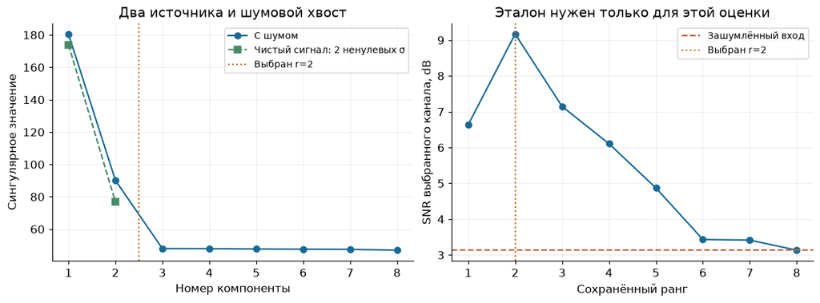

```python
def snr_db(reference, estimate):
    error_energy = np.sum((estimate - reference)**2)
    return 10 * np.log10(np.sum(reference**2) / max(error_energy, np.finfo(float).tiny))


channel = LISTEN_CHANNEL
input_snr = snr_db(clean[channel], noisy[channel])
rows = []
for rank in range(1, len(singular_values) + 1):
    estimate = reconstruct(rank)
    projector = U[:, :rank] @ U[:, :rank].T
    retained_weak = np.linalg.norm(projector @ A[:, 1])**2 / np.linalg.norm(A[:, 1])**2
    clean_distortion = np.linalg.norm(projector @ clean - clean) / np.linalg.norm(clean)
    rows.append({
        'rank': rank,
        'SNR, dB': snr_db(clean[channel], estimate[channel]),
        'gain vs noisy, dB': snr_db(clean[channel], estimate[channel]) - input_snr,
        'weak source retained, %': 100 * retained_weak,
        'clean projection distortion, %': 100 * clean_distortion,
    })
metrics = pd.DataFrame(rows)
metrics.to_csv(OUTPUT_DIR / 'rank_metrics.csv', index=False)
display(metrics.round(3))
print(f'Input SNR, channel {channel}: {input_snr:.2f} dB')
print(f'Chosen rank {KEEP_RANK}: SNR = {snr_db(clean[channel], denoised[channel]):.2f} dB')
oracle_rank = int(metrics.loc[metrics['SNR, dB'].idxmax(), 'rank'])
print(f'Best rank by this known clean reference: {oracle_rank} (oracle diagnostic only)')

# Качество — наблюдаемый результат, а не инвариант алгоритма.
# При изменении амплитуд или шума тихий источник может потеряться и при ранге 2.
print('Сохранено тихого источника при r=1 и r=2, %:',
      metrics.loc[metrics['rank'].isin([1, 2]), 'weak source retained, %'].round(3).tolist())

fig, axes = plt.subplots(1, 2, figsize=(11, 4), layout='constrained')
indices = np.arange(1, len(singular_values) + 1)
axes[0].plot(indices, singular_values, 'o-', color='#186a95', label='С шумом')
axes[0].plot(indices[:2], clean_singular_values[:2], 's--', color='#478a66',
             label='Чистый сигнал: 2 ненулевых σ')
axes[0].axvline(KEEP_RANK + 0.5, color='#bc6f29', ls=':', label=f'Выбран r={KEEP_RANK}')
axes[0].set(xlabel='Номер компоненты', ylabel='Сингулярное значение', xticks=indices,
            title='Два источника и шумовой хвост')
axes[0].legend(fontsize=9)
axes[1].plot(metrics['rank'], metrics['SNR, dB'], 'o-', color='#186a95')
axes[1].axhline(input_snr, color='#bd6543', ls='--', label='Зашумлённый вход')
axes[1].axvline(KEEP_RANK, color='#bc6f29', ls=':', label=f'Выбран r={KEEP_RANK}')
axes[1].set(xlabel='Сохранённый ранг', ylabel='SNR выбранного канала, dB',
            xticks=indices, title='Эталон нужен только для этой оценки')
axes[1].legend(fontsize=9)
fig.savefig(OUTPUT_DIR / 'rank_tradeoff.png', bbox_inches='tight')
plt.show()
```

## 4. Слушаем при одинаковом усилении

Ни один проигрыватель не нормализует свою дорожку отдельно. Один общий коэффициент усиления рассчитывается по максимальному пику **всех сравниваемых дорожек**; после него пики не превышают 0.95. Поэтому ослабление мелодии не маскируется автоматическим увеличением громкости. Отрегулируйте громкость устройства один раз для всего сравнения.

Сначала сравните чистую смесь и шумный вход. Затем послушайте ранг 1: шум ослаб, но исчезает тихая верхняя мелодия. При ранге 2 она возвращается. Общий SNR — не исчерпывающая оценка качества: потеря небольшой, но смысловой детали может быть важна, даже если SNR вырос.

```python
audio_signals = {
    'clean': clean[channel],
    'noisy': noisy[channel],
    'rank1': rank1[channel],
    'rank2': rank2[channel],
}
if KEEP_RANK != 2:
    audio_signals[f'chosen_rank{KEEP_RANK}'] = denoised[channel]
common_peak = max(float(np.max(np.abs(x))) for x in audio_signals.values())
common_gain = 0.95 / max(common_peak, np.finfo(float).eps)
print(f'Channel: {channel}; common playback gain: {common_gain:.4f}; normalize=False')

labels = {
    'clean': 'Чистая смесь: две полезные мелодии',
    'noisy': 'Зашумлённая смесь',
    'rank1': 'Ранг 1: тихая верхняя мелодия теряется',
    'rank2': 'Ранг 2: обе мелодии и остаточный шум',
}
for name, x in audio_signals.items():
    played = common_gain * x
    assert np.all(np.isfinite(played)) and np.max(np.abs(played)) <= 0.9500001
    display(Markdown(f'**{labels.get(name, name)}**'))
    display(Audio(played, rate=FS, normalize=False))
    if WRITE_WAV:
        # Float32 WAV: тот же фиксированный gain, без клиппинга и независимой нормализации.
        wavfile.write(OUTPUT_DIR / f'{name}_channel{channel}.wav', FS, played.astype(np.float32))
```

```
Channel: 0; common playback gain: 0.5640; normalize=False
```

**Чистая смесь: две полезные мелодии**

[interactive chart not shown]

**Зашумлённая смесь**

[interactive chart not shown]

**Ранг 1: тихая верхняя мелодия теряется**

[interactive chart not shown]

**Ранг 2: обе мелодии и остаточный шум**

[interactive chart not shown]

## 5. Волновые формы и спектрограммы

Волновые формы имеют одинаковые оси. Обзор за четыре секунды показан min/max-огибающей: каждый блок из 64 исходных отсчётов сохраняет оба экстремума, без прореживания аудио. При FS = 8 кГц это 8 мс. Такой обзор показывает амплитуду, а не форму отдельных колебаний. В увеличенном участке показаны все исходные отсчёты. На спектрограммах также общий диапазон цвета относительно одного пикового значения STFT. STFT здесь используется **только для визуализации**; SVD выполнялся над матрицей каналов, и восстановление звука не требует обратной STFT или подстановки фазы.

Ищите тихие верхние ноты около 523–784 Гц и их гармоники: при ранге 1 они пропадают, хотя шумовая «подложка» становится слабее.

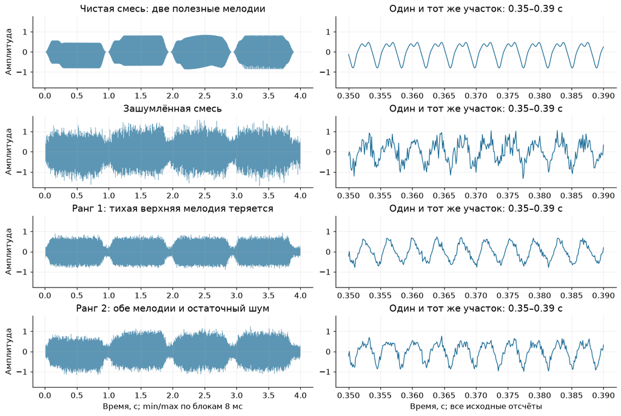

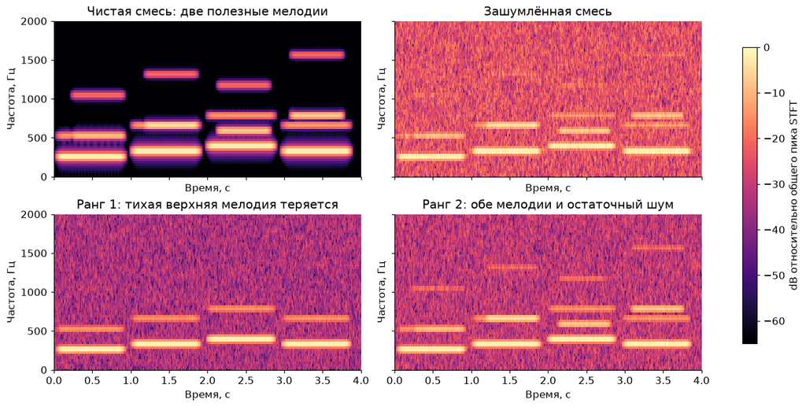

```python
view_names = ['clean', 'noisy', 'rank1', 'rank2']
fig, axes = plt.subplots(4, 2, figsize=(12, 8), layout='constrained')
wave_limit = 1.05 * max(np.max(np.abs(audio_signals[name])) for name in view_names)
zoom = (t >= 0.35) & (t <= 0.39)
for row, name in enumerate(view_names):
    x = audio_signals[name]
    plot_minmax_envelope(axes[row, 0], t, x, color='#186a95')
    axes[row, 1].plot(t[zoom], x[zoom], lw=1, color='#186a95')
    axes[row, 0].set(title=labels[name], ylabel='Амплитуда', ylim=(-wave_limit, wave_limit))
    axes[row, 1].set(title='Один и тот же участок: 0.35–0.39 с', ylim=(-wave_limit, wave_limit))
axes[-1, 0].set_xlabel(f'Время, с; min/max по блокам {64 / FS * 1000:g} мс')
axes[-1, 1].set_xlabel('Время, с; все исходные отсчёты')
fig.savefig(OUTPUT_DIR / 'waveforms.png', bbox_inches='tight')
plt.show()

window = signal.windows.hann(256, sym=False)
spectra = {}
for name in view_names:
    frequencies, frame_times, Z = signal.stft(
        audio_signals[name], fs=FS, window=window, nperseg=256,
        noverlap=192, boundary='zeros', padded=True,
    )
    spectra[name] = np.abs(Z)
shared_reference = max(float(magnitude.max()) for magnitude in spectra.values())
fig, axes = plt.subplots(2, 2, figsize=(12, 6), sharex=True, sharey=True, layout='constrained')
for ax, name in zip(axes.flat, view_names):
    db = 20 * np.log10(np.maximum(spectra[name] / shared_reference, 1e-6))
    image = ax.pcolormesh(frame_times, frequencies, db, shading='auto',
                         cmap='magma', vmin=-65, vmax=0)
    ax.set(title=labels[name], ylim=(0, 2_000), xlabel='Время, с', ylabel='Частота, Гц')
    ax.grid(False)
fig.colorbar(image, ax=axes, label='dB относительно общего пика STFT', shrink=0.85)
fig.savefig(OUTPUT_DIR / 'spectrograms.png', bbox_inches='tight')
plt.show()
```

## 6. Что получилось и где заканчивается модель

1. При полном ранге восстанавливается весь вход, включая шум. Ранг 2 снижает ошибку в этой сцене, потому что полезные сигналы занимают общее двумерное подпространство восьми каналов, а независимый шум распределён по всем направлениям.
2. Ранг 1 может повысить SNR относительно шумного входа и одновременно почти полностью удалить тихую полезную мелодию. Малое сингулярное значение не означает «только шум».
3. Сильная общая помеха, например синхронный гул во всех каналах, тоже может попасть в ведущую компоненту. SVD сортирует энергию, а не полезность. Для речи, реверберации и нестационарного шума результаты будут зависеть от представления и задачи.
4. Здесь rank-2 усечение минимизирует матричную ошибку приближения **наблюдаемой** матрицы в норме Фробениуса; это не обещание оптимального perceptual quality и не универсальная гарантия роста SNR относительно неизвестного чистого звука.

### Небольшие эксперименты

- Поставьте `KEEP_RANK = 1`, затем `4` и `8`, перезапуская все ячейки. Сопоставьте SNR, слух и спектрограмму.
- Измените `NOISE_SNR_DB` на `-5` и `10`. Когда спектральный разрыв становится трудно заметить?
- Уменьшите амплитуду второго источника. Насколько надёжен выбор ранга по одному графику сингулярных значений?
- Добавьте во все каналы один громкий 120-Гц синус с одинаковой фазой. Он структурирован и может сохраниться после усечения: сильная компонента не обязательно полезна.

### Если хочется применить к собственной записи

Нужен синхронный многоканальный WAV: матрица для SVD имеет форму `channels × samples`, например результат чтения `scipy.io.wavfile.read(...)[1].T`. Уберите постоянную составляющую при необходимости и отдельно продумайте её восстановление. Не усредняйте каналы заранее: это уничтожит пространственную структуру. Два стереоканала дают максимум ранг 2 и очень ограниченный выбор; левый и правый каналы музыкального микса не эквивалентны микрофонному массиву.

У моно WAV матрица `1 × samples` уже имеет ранг 1 — такое усечение не удалит шум. Для моно нужно сначала построить другое представление, например Hankel/SSA или временно-частотную матрицу, и корректно вернуться к волновой форме. Это другой эксперимент. Если чистого эталона нет, **не вычисляйте и не заявляйте clean SNR**: оценивайте слух, артефакты и характеристики, доступные для вашей задачи.

### Проверенные первичные источники

- [NumPy: `numpy.linalg.svd`](https://numpy.org/doc/stable/reference/generated/numpy.linalg.svd.html) — формы факторов, порядок сингулярных значений и восстановление матрицы.
- [SciPy: `scipy.signal.stft`](https://docs.scipy.org/doc/scipy/reference/generated/scipy.signal.stft.html) — временно-частотное представление и параметры окон; здесь только визуализация. Эта совместимая функция отмечена SciPy как legacy; для нового расширенного STFT-кода есть `ShortTimeFFT`.
- [SciPy: `scipy.io.wavfile.write`](https://docs.scipy.org/doc/scipy/reference/generated/scipy.io.wavfile.write.html) — формат экспортируемого WAV.

Описание синтеза и смешивания выше полностью задаёт происхождение данных. Численные результаты этого ноутбука относятся только к данной синтетической сцене, а не к исследованию ультразвука, указанному на исходном слайде.

```python
assert all(np.isfinite(x).all() for x in audio_signals.values())
assert np.isfinite(metrics['SNR, dB']).all()
assert np.isclose(metrics.loc[metrics['rank'] == 8, 'SNR, dB'].iloc[0], input_snr, atol=1e-9)
print('Проверки пройдены: формы, конечность, full-rank восстановление и согласованность SNR.')
print('Файлы:', ', '.join(path.name for path in sorted(OUTPUT_DIR.iterdir())))
```

```
Проверки пройдены: формы, конечность, full-rank восстановление и согласованность SNR.
Файлы: clean_channel0.wav, noisy_channel0.wav, rank1_channel0.wav, rank2_channel0.wav, rank_metrics.csv, rank_tradeoff.png, sources.png, spectrograms.png, waveforms.png
```